# Ordinal models

Ben Bolker

## Load packages …

```r
## fitting
library(MASS) ## polr
library(ordinal)
library(tidyverse); theme_set(theme_bw())
## Bayesian solutions
library(MCMCglmm)
library(brms)
library(patchwork)
## remotes::install_github("https://github.com/bbolker/ordinalsim")
library(ordinalsim)
library(sure)
```

## Goal

- estimate effects of categorical and continuous predictors when the response is *ordinal*
- categorical but ordered; we don’t know distances between successive levels
- CLM = **cumulative link** model

## house data

“Frequency table from a Copenhagen housing conditions survey”

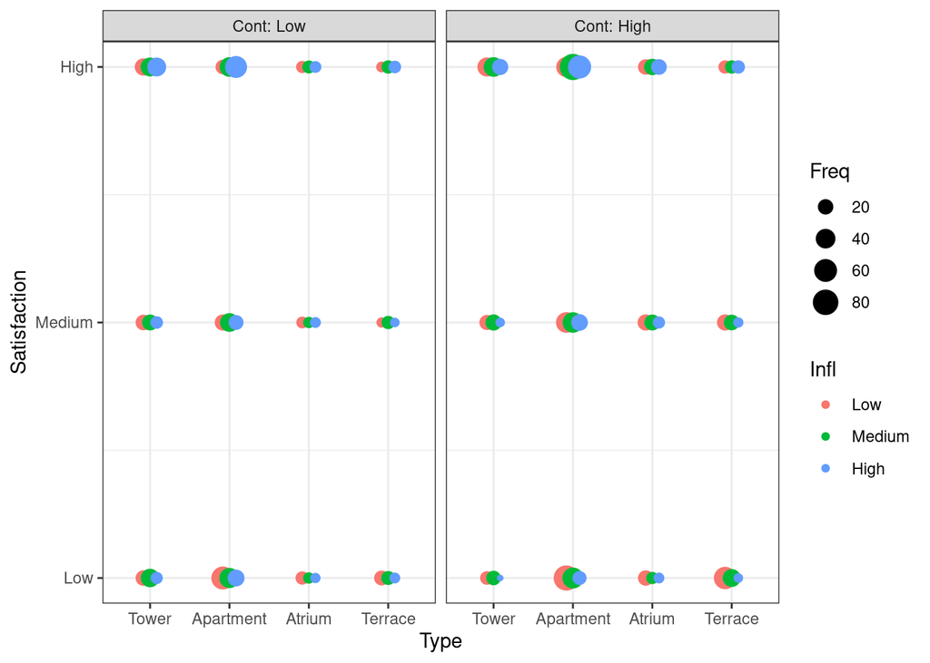

```r
## FIXME: compute weighted means
pd <- position_dodge(width = 0.25)
ggplot(housing, aes(x=Type, y = as.numeric(Sat), colour = Infl)) +
  geom_point(aes(size=Freq), position = pd) +
  facet_wrap(~Cont, labeller = label_both) +
  scale_y_continuous(breaks = 1:3,
                     labels = levels(housing$Sat)) +
  labs(y = "Satisfaction")
```

```r
house.plr <- polr(Sat ~ Infl + Type + Cont, weights = Freq, data = housing)
print(ss <- summary(house.plr))
```

```
##
## Re-fitting to get Hessian
```

```
## Call:
## polr(formula = Sat ~ Infl + Type + Cont, data = housing, weights = Freq)
##
## Coefficients:
##                 Value Std. Error t value
## InflMedium     0.5664    0.10465   5.412
## InflHigh       1.2888    0.12716  10.136
## TypeApartment -0.5724    0.11924  -4.800
## TypeAtrium    -0.3662    0.15517  -2.360
## TypeTerrace   -1.0910    0.15149  -7.202
## ContHigh       0.3603    0.09554   3.771
##
## Intercepts:
##             Value   Std. Error t value
## Low|Medium  -0.4961  0.1248    -3.9739
## Medium|High  0.6907  0.1255     5.5049
##
## Residual Deviance: 3479.149
## AIC: 3495.149
```

Understanding the intercept terms:

```r
## select baseline predictors (first level of each factor)
get_pframe <- function(Infl_sel = "Low",
                       Type_sel = "Tower",
                       Cont_sel = "Low") {
  subset(housing,
                 Infl == Infl_sel &
                 Type == Type_sel &
                 Cont == Cont_sel,
                 select = -c(Sat, Freq))[1,]
}

pframe <- get_pframe()
## predict probs from fitted model
(probs <- predict(house.plr, newdata = pframe, type = "probs"))
```

```
##       Low    Medium      High
## 0.3784493 0.2876752 0.3338755
```

```r
zeta <- ss$zeta

## hand calculation
c(plogis(zeta[1]), diff(plogis(zeta)), 1-plogis(zeta[2]))
```

```
##  Low|Medium Medium|High Medium|High
##   0.3784493   0.2876752   0.3338755
```

Gambarota and Altoè (2024)

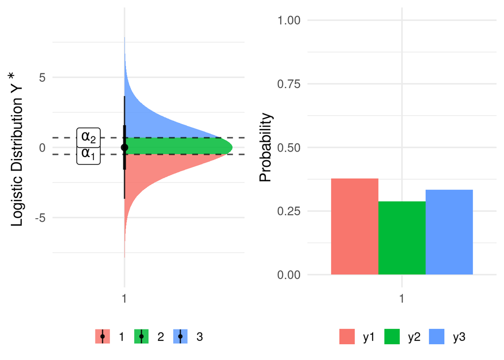

```r
cat_latent_plot(prob = probs)
```

## Assumptions

- independence
- **proportional odds** or equivalent: changes to predictors (change in category, or a change in a numeric variable) shifts log-odds of neighbouring categories (Medium vs Low, High vs Medium) up or down by the *same amount*
- linearity of effects on this log-odds scale

## Alternative links

- logit (log-odds): *proportional odds*
- probit: very similar. Interpretable as shifting the distribution of a Gaussian latent variable

## Diagnostics

`DHARMa`, `performance::check_model()` Seem to be terrible … ? Greenwell et al. (2018)

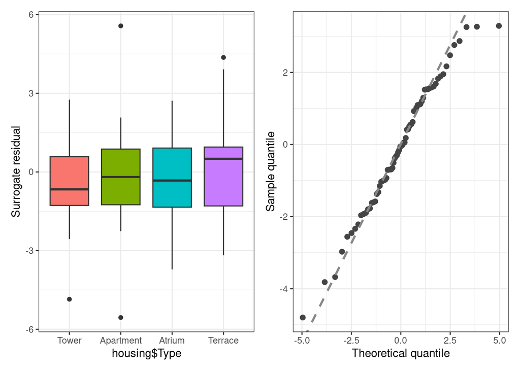

```r
set.seed(101)  # for reproducibility
sres <- resids(house.plr)
p1 <- autoplot.polr(house.plr, what = "covariate", x = housing$Type)
p2 <- autoplot.polr(house.plr, what = "qq")
p1 + p2
```

May not work with `clmm`, `clmm2` (mixed models)?

[Frank Harrell on evaluating PO assumptions](https://www.fharrell.com/post/impactpo/)

## other packages

- `rms::orm`
- for mixed models: `ordinal` (`?residuals.lrm`)
- Bayesian mixed models: `brms`, `MCMCglmm`, …

## ordinal package

- works with `emmeans`, `effects`, etc.
- testing proportionality: can set effects of some variables to be *nominal* (more flexible, allow non-proportionality) with `nominal = ~ ...`

## Example

```r
fit2 <- clm(Sat ~ Infl + Type + Cont, weights = Freq, data = housing)
summary(fit2)
```

```
## formula: Sat ~ Infl + Type + Cont
## data:    housing
##
##  link  threshold nobs logLik   AIC     niter max.grad cond.H
##  logit flexible  1681 -1739.57 3495.15 4(0)  6.60e-09 4.7e+01
##
## Coefficients:
##               Estimate Std. Error z value Pr(>|z|)
## InflMedium     0.56639    0.10465   5.412 6.23e-08 ***
## InflHigh       1.28882    0.12716  10.136  < 2e-16 ***
## TypeApartment -0.57235    0.11924  -4.800 1.59e-06 ***
## TypeAtrium    -0.36619    0.15517  -2.360 0.018282 *
## TypeTerrace   -1.09101    0.15149  -7.202 5.93e-13 ***
## ContHigh       0.36028    0.09554   3.771 0.000162 ***
## ---
## Signif. codes:  0 '***' 0.001 '**' 0.01 '*' 0.05 '.' 0.1 ' ' 1
##
## Threshold coefficients:
##             Estimate Std. Error z value
## Low|Medium   -0.4961     0.1248  -3.974
## Medium|High   0.6907     0.1255   5.505
```

```r
predict(fit2, newdata = pframe, se.fit = TRUE) ## probs
```

```
## $fit
##         Low    Medium      High
## 1 0.3784494 0.2876751 0.3338755
##
## $se.fit
##          Low     Medium       High
## 1 0.02936725 0.01174062 0.02790529
```

[Frank Harrell on PO models](https://www.fharrell.com/post/rpo/)

## References

Gambarota, Filippo, and Gianmarco Altoè. 2024. “Ordinal Regression Models Made Easy: A Tutorial on Parameter Interpretation, Data Simulation and Power Analysis.” *International Journal of Psychology* 59 (6): 1263–92. https://doi.org/10.1002/ijop.13243.

Greenwell, Brandon M., Andrew McCarthy, Bradley C. Boehmke, and Dungang Liu. 2018. “Residuals and Diagnostics for Binary and Ordinal Regression Models: An Introduction to the Sure Package.” *The R Journal* 10 (1): 381–94. https://doi.org/10.32614/RJ-2018-004.